# ggplot2::expand_limits()

# Function of the Week: expand_limits()

Abe Ahn

2023-02-21

# Submission Instructions

Please sign up for a function here: https://docs.google.com/spreadsheets/d/1-RWAQTlLwttjFuZVAtSs8OiHIwu6AZLUdWugIHHTWVo/edit?usp=sharing

For this assignment, please submit both the `.Rmd` and the `.html` files. I will add it to the website. Remove your name from the Rmd if you do not wish it shared. If you select a function which was [presented last year](https://sph-r-programming.netlify.app/functions/), please develop your own examples and content.

# `expand_limits()`

In this document, I will introduce the **expand_limits()** function and show what it’s for.

```r
#load tidyverse up
library(tidyverse)
#example dataset
library(palmerpenguins)
data(penguins)
```

## What is it for?

> Discuss what the function does. Learn from the examples, but show how to use it using another dataset such as `penguins`. If you can provide two examples, even better!

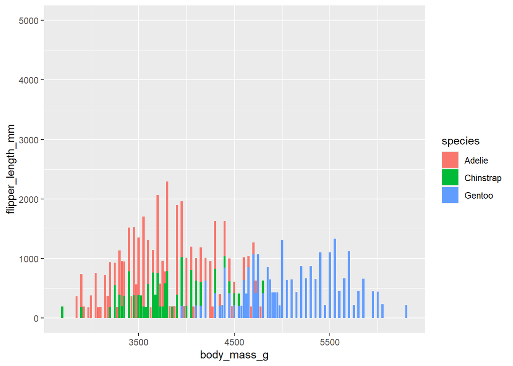

```r
# Used to define the limits of a single value, for both panels and plots, able to wrap around any geom function

peng_mass <- ggplot(penguins,
       aes (x = body_mass_g,
            y = flipper_length_mm,
            fill = species)) +
  geom_col()

peng_mass + expand_limits(y = c(1, 5000))
```

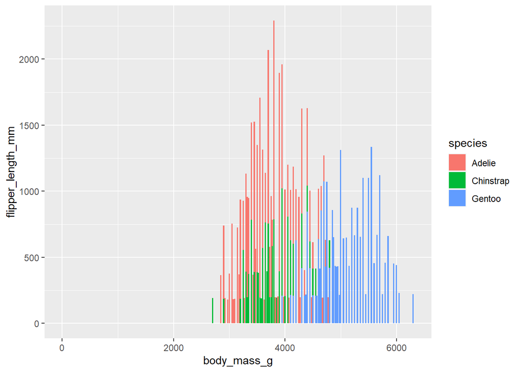

```r
# Sometimes you can use expand_limits() to change the range of both x and y values!

peng_mass + expand_limits(x = 0, y = 0)
```

## Is it helpful?

> Discuss whether you think this function is useful for you and your work. Is it the best thing since sliced bread, or is it not really relevant to your work?

I would say that it is helpful to adjust the values of the x and y axis manually if you do not want ggplot to automatically set the origin to the lowest value. expand_limits() can also allow you to change the color according to the range you highlight.

Reference: https://ggplot2.tidyverse.org/reference/expand_limits.html

Last updated on March 5, 2023

[Edit this page](https://github.com/jminnier/sph_r_programming_site/edit/master/content/functions/ggplot2_expand_limits.html)